# 771 Class 9

### Wednesday 2/21/18

### Topics in convex optimization

Continuing from last time, let’s have a convex set $C \subset R^n$, and recall both the indicator function $1_C(x)$ and the normal cone $N_C(x)=\{g \in R^n: \; g^T x \geq g^T y \; \forall y \in C\}$ introduced last time.

[examples of some normal cones in simple sets, where $x=0$]

Recall at least that when $0 \in C$, $N_C(0)$ is the set of vectors $g$ making non-positive inner product with all vectors in $C$.

#### Differentiable convex functions subject to convexity constraints

We’re thinking about statistical estimation problems in which the parameter estimate is minimizes a certin objective function (e.g. negative log likelihood) subject to some structural constraint on the parameters. This fits into a general class of optimization problems.

Say $f$ is differentiable and convex, so an unconstrained global optimizer $x^*$ would satisfy $\nabla f (x^*) = 0$. But we also require our solution to be restricted to a convex set $C$. To provide for this, it’s enough that $x^*$ be the global optimizer of the modified function
$$f(x) + 1_C(x)$$
We know from subgradient optimality that for $x^*$ to solve this it must be that $0 \in \partial[ f(x) + 1_C(x) ]$. Using the addititivity property of subdifferentials and the connection just made to normal cones, any subgradient in this subdifferential must be the sum of $\nabla f(x^*)$ and some vector $v$ in the normal cone of $C$ at $x^*$. I.e., $-\nabla f(x^*)$ must be in the normal cone of $C$ at $x^*$:
$$[-\nabla f (x^*) ]^T (x^* - y) \geq 0 \qquad \forall y \in C$$
This important formula is sometimes called *first-order optimality*. It characterizes any solution $x^*$ that minimizes a differentiable convex function $f$ subject to convex constraints $C$.

First-order optimality may not be useful in that it’s not a prescription for computing $x^*$. But if you have a candidate $x^*$ you may check that is in fact a proper solution.

Curiously, this general theory covers a range of specialized cases we may know about already:

1. $C=R^n$. Then there are really no constraints, and the formula holds when $x^*$ is chosen so that $\nabla f(x^*) = 0$, which we already knew from calculus characterizes the optimizer.
2. $C$ is a set of linear equality constraints. Here we take an example to help us. Consider observed multinomial counts $\{y_k\}$ from $n$ i.i.d. trials on a discrete population, with type $k$ occuring with probability $p_k$. The negative log likelihood for the full vector of propertions, $p$, is $f(p) = -\sum_{k=1}^K y_k \log(p_k)$. We are familiar with the finding that the MLE is $\hat p_k = y_k/n$. This involves minimizing $f$ subject to the constraint that $\sum_k p_k=1$, and is readily developed using a Lagrange multiplier. On the other hand, we could consider $f$ at first unconstrained, and then require our solution to live in the convex set $C=\{p: \sum_k p_k =1 , \; p_k \geq 0\}$. By this route, the gradient $\nabla f (\hat p)$ has entries $- y_k/\hat p_k = -n$, and the first-order optimality condition holds immediately:
   $$[\nabla f(\hat p)]^T(p- \hat p) = \sum_{k=1}^K (-n) (p_k - \hat p_k) = 0.$$
3. $C$ is a set of linear equality and inequality constraints. The powerful KKT theory covers this case, and provides specificity for $x^*$. But KKT is superceded by first-order optimality, in the sense that a KKT solution has to also be a solution to the formula above.

#### Case: MLE for ordered means

As an example, suppose data are $\{ (i, Y_i): i=1,2, \cdots, n \}$ and our model is that the measurements are independent and governed by:
$$Y_i \sim \mbox{Normal}(\mu_i, \sigma^2)$$
Say the observed value of $Y_i$ is $y_i$.

Let $\mu = (\mu_1,\mu_2,...\mu_n)^T$ be the parameter of interest. As in our treatment of regression, we’ll initially ignore $\sigma^2$, since we know that the MLE of $\mu$, regardless of $\sigma^2$, must minimize the objective:

$$f(\mu) = (1/2) \sum_{i=1}^n (y_i - \mu_i)^2$$

Without constraints $\hat \mu_i = y_i$, and we’d probably be overfitting the system. We add structure to the problem by requiring our solution to be have ordered components; i.e. to lie in the convex set $C$:
$$C = \{ \mu: \; \mu_1 \leq \mu_2 \leq \cdots \leq \mu_n \}$$

Finding the MLE subject to $\mu \in C$ is a tricky problem, but one that the current theory provides for, since $f$ is convex and differentiable and $C$ is convex. Accordingly, our solution $\hat \mu$ must satisfy first-order optimality:
$$[ \nabla f(\hat \mu) ]^T (\mu - \hat \mu) \geq 0 \qquad \forall \mu \in C$$
We know further that $\nabla f(\mu)$ has components $\mu_i - y_i$, and so whatever is our solution it must satisfy:
$$\sum_{i=1}^n (\hat \mu_i - y_i)( \mu_i - \hat \mu_i) \geq 0 \qquad \forall \mu \in C$$

We’re not out of the woods, but we’ve made some progress. To go further, let’s first make a diversion.

#### Cumulative sum diagram (CSD)

Consider a two-dimensional plot of points

$$P_i = \left( i, \sum_{j=1}^i y_j \right) \qquad i=1,2, \cdots, n,$$

and including $P_0=(0,0)$. Let $H_n(t)$ denote the function that interpolates these points. Plotting $H_n$ creates the so-called *cumulative sum diagram*.

#### Greatest convex minorant (GCM)

The GCM, denoted $H(t)$, say, is the pointwise supremum of all convex functions lying below $H_n$, and is itself convex. Notice this function is piecewise linear.

#### Left-derivative of GCM

**Claim:** The left derivatives of the GCM of the CSD (i.e., the $\tilde \mu_i$’s) are the maximum likelihood estimates of $\mu_i$ subject to the ordering constraint $C$.

[sketch the CSD and GCM in one case]

In class we work through the toy example $y=(0,1,1,0,0,1,1,1)$.

#### Proof that left-derivative of GCM of CSD satisfies first-order optimality

The first-order optimality criteria would hold for the $\tilde \mu_i$’s if
$$[\nabla f( \tilde \mu )]^T (\mu - \tilde \mu) \geq 0 \qquad \forall \mu \in C$$
Recall that the gradient has entries $\tilde \mu_i - y_i$, and so the critical value (that we aim to show is non-negative) is
$$\sum_{i=1}^n (\tilde \mu_i - y_i) (\mu_i - \tilde \mu_i) = \sum_{i=1}^n d_i \mu_i - \sum_{i=1}^n d_i \tilde \mu_i$$
where $d_i = \tilde \mu_i - y_i$. Call this $A-B$, and work on each piece separately.

To sort either, notice the ordering constraint means that any $\mu \in C$ may be expressed in terms of other parameters $\alpha_0, \alpha_1, \cdots, \alpha_{n-1}$, with $\alpha_j \geq 0$ for $j=1,2 \cdots, n-1$. These are the jumps associated with increases in $\mu_i$. Therefore
$$\mu_i = \alpha_0 + \sum_{j=1}^{n-1} \alpha_j 1[j < i]$$
Thus
$$A=\sum_{i=1}^n d_i \left( \alpha_0 + \sum_{j=1}^{n-1} \alpha_j 1[j < i] \right)$$
Simplifying, and switching the summation order
$$A = \alpha_0 \sum_{i=1}^n d_i + \sum_{j=1}^{n-1} \alpha_j \sum_{i=1}^{n} d_i 1[j < i]$$
The characterization of the $\tilde \mu_i$’s (specifically, the $i=n$ case) proves that $\sum_{i=1}^n d_i = 0$. This gives
$$A = \sum_{j=1}^{n-1} \alpha_j \left( - \sum_{i=1}^j d_i \right)$$
Both components in the sum over $j$ are non-negative, since $\alpha_j \geq 0$ by the ordering constraint and the sum in brackets is non-negative by the characterization.

It remains to prove that $B=0$. Expanding from above,
$$B=\sum_{i=1}^n d_i \left( \tilde \alpha_0 + \sum_{j=1}^{n-1} \tilde \alpha_j 1[j < i] \right)$$
where the $\tilde \alpha_j$’s are deviations associated with $\tilde \mu$. Simplifying
$$B = \sum_{j=1}^{n-1} \tilde \alpha_j \left( \sum_{i=j+1}^n d_j \right) = - \sum_{j=1}^n \tilde \alpha_j \left( \sum_{i=1}^j d_i \right)$$
. Now we consider the two factors in each summand on the right side above. From the characterization of the $\tilde \mu_i$’s , each $\tilde \alpha_j$ is either 0 or positive. The key is to observe that when it’s positive, the other factor $\sum_{i=1}^j d_i$ equals zero, thus completing the proof.

#### Pool Adjacent Violators

PAVA is a step-wise algorithm that ends in a finite number of steps at the exact solution (in contrast to other iterative algorithms that we’ll see later which continue until some tolerance is met).

One way to describe it is to say at each step `t` there are sets S1, S2, …, SJ constituing contiguous sets of integers in `1:n`, there are *tentative* estimates muhat_{sj}, and weights w_{Sj}:

```
Initialize:  set Sj = {j}; weight w_j = 1, and estimate muhat_{Sj} = y_j.

A. Find adjacent violators. I.e.,  where
         muhat_{Sj} > muhat_{S(j+1)}

If no violators: stop.

If adjacent violators:

Pool by computing:
        bar <- [w_{Sj}+w_{S(j+1)}]
        tmp <- [w_{Sj} muhat_{Sj} + w_{S(j+1)} muhat_{S(j+1)} ]/bar

Update the system:

                merge   sets  Sk <- Sk  k < j
                              Sj <- Sj union S(j+1)
                              Sk <- S(k+1) , k >= j+1

                compute means muhat_{Sk} <-  muhat_{Sk}  k < j
                              muhat_{Sj} <-  tmp
                              muhat_{Sk} <-  muhat_{S(k+1)},  k>j, k<n.

                merge weights  w_{Sk} <- w_{sk}    k < j
                               w_{Sj} <- bar
                               w_{Sk} <- w_{s(k+1)}  k >j, k < n

Go to A.

Get final estimates by tracing back:
                               muhat.j <- muhat_{S}  if j in S
```

Here’s how it works on the toy example

```
          i   1    2    3    4    5    6    7    8
        y_i   0    1    1    0    0    1    1    1

        w_i   1    1    1    1    1    1    1    1

    y_i/w_i  0/1  1/1  1/1  0/1  0/1  1/1  1/1  1/1
                        ------ violators

             0/1  1/1     1/2    0/1  1/1  1/1  1/1
                  ---------- violators

             0/1      2/3        0/1  1/1  1/1  1/1
                      -------------- violators

             0/1            2/4       1/1  1/1  1/1  *no more violators*

    Traceback: muhat = (0, 1/2,1/2,1/2,1/2, 1,1,1 )
```

#### Example: Ice-on time

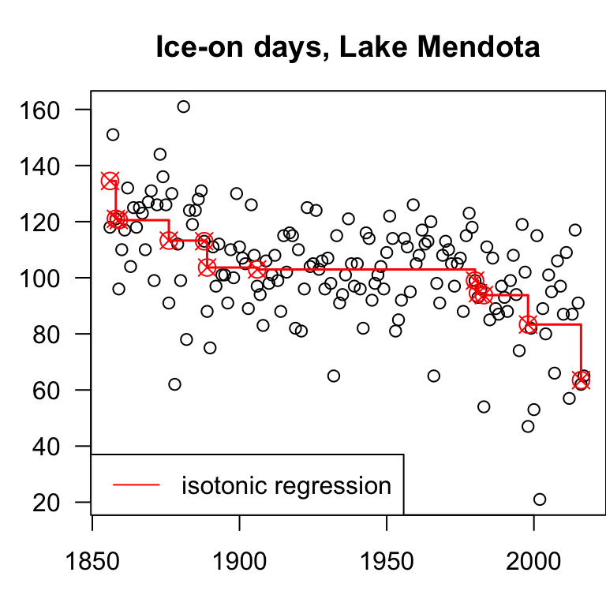

```r
dat <- read.csv("MendotaIce.csv",header=TRUE)

# use isoreg, built-in PAVA-code for increasing isotonic regression;

x0 <- 2018 - dat$WINTER   # so we can consider non-decreasing
y0 <- dat$DAYS

ok <- !is.na(y0)   # clean data
x <- x0[ok] ; y <- y0[ok]
fit <- isoreg( x, y )

fit$x <- dat$WINTER[ok]
par( mar=c(3,3,3,0))
plot(fit, main="Ice-on days, Lake Mendota", xlab="year", ylab="days", las=1 )
legend( "bottomleft", legend="isotonic regression", lwd=1, col="red" )
```

#### Related work

Recent research provides a new view on isotonic regression. Instead of forcing strict, hard constraints on monotonicity, this work explores an approach to making a softer constraint. Connections to fused LASSO and data on word-wide temperature changes are discussed.

[Tibshirani, Hofling, and Tibshirani, 2017](https://www.researchgate.net/publication/229007529_Nearly-Isotonic_Regression)

The R function `isoreg` provides for standard isotonic regression. A more fully developed package `isotone` is available at CRAN. The authors provide a very sophisticated vignette on algorithmic approaches to the ordered means and related problems: [de Leeuw, Hornik, and Mair](https://cran.r-project.org/web/packages/isotone/vignettes/isotone.pdf)

PAVA was first introduced by Ayer and colleagues in the context of the ordered-binomial-probabilities problem, which we’ll discuss briefly next time: [Ayer, Brunk, Ewing, Reid, and Silverman, 1955](http://www.jstor.org/stable/2236377?seq=1#page_scan_tab_contents)

A useful textbook presentation is [Groeneboom and Jongbloed, Nonparametric Estimation Under Shape Constraints](https://www.cambridge.org/core/books/nonparametric-estimation-under-shape-constraints/881B662EEF5B5266E5E4D80E6153FCDA)